# EnWAS Base Model: Diasatolic-Blood Pressure

Updated on : Wed Oct 19 13:07:46 2022

## Load libs and Load data

The process of load libs and data is the same as [EnWAS sample](https://ccb-hms.github.io/Imputation/7_enwas/EnWAS_simple.html).

## Query Extra data

This part loads the blood pressure data and merges it with the dietary and demographic data in the above section.

```r
set.seed(123)
nhanes_db <- dbConnect(RSQLite::SQLite(), "../../nhanes.sqlite")
# BPXDI2,BPXSY1
blood_pressure <- dbGetQuery(nhanes_db, "select SEQN, BPXDI1,BPXDI2 from BloodPressure where BPXDI1 IS NOT NULL and BPXDI1 <> 0 and BPXDI2 IS NOT NULL and BPXDI2 <> 0")

dbDisconnect(nhanes_db)
blood_pressure$diastolic <- rowMeans(blood_pressure[, c('BPXDI1','BPXDI2')])


data <- merge(blood_pressure, data, by = "SEQN")
data <- data[sample(1:nrow(data)), ] # shuffle the data
data$years <- as.factor(data$years)
ethnicity <-
  c(
    'Mexican American',
    'Other Hispanic',
    'Non-Hispanic White',
    'Non-Hispanic Black',
    'Other Race'
  )

levels(data$RIDRETH1) <- ethnicity
```

## Base Model

```r
lm_str <- 'diastolic ~ RIDAGEYR*RIAGENDR + BMXBMI + RIDRETH1'
lm_base <- lm(as.formula(lm_str), data)

ns_str <-
  'diastolic ~ ns(RIDAGEYR, knots = seq(30, 80, by = 10), Boundary.knots=c(20,90)) * RIAGENDR + ns(BMXBMI,knots = c(seq(15, 45, by = 5),seq(45,65,by=10)),Boundary.knots=c(10,85)) + RIDRETH1'
ns_base <- lm(as.formula(ns_str), data)
```

## Bins plot functions

```r
library(ggpubr)
library(reshape)

plot_bins<- function(x,y,xlab="Value",ylab="Binned Residuals",title="linear",nbin=600){

  df <- make_bins(x,y,nbin)
  g <- ggplot(df,aes(breaks,mean)) + geom_point() +
  geom_errorbar(aes(ymin=y_min,ymax=y_max))+
  geom_smooth(aes(breaks,mean),method = "lm", formula = y ~  ns(x, df=7))+
  ylab(ylab) + xlab(xlab) + labs(title = title)

 g

}
```

## Diastolic: Blood pres (1st rdg) mm Hg

This section compares linear and spline regression of Diastolic blood pressure against age and BMI.

```r
pred_df <- data.frame("Age"=data$RIDAGEYR,
                      "Gender"=data$RIAGENDR,
                      "BMI"=data$BMXBMI,
                      "Linear"=lm_base$fitted.values,
                      "Spline"=ns_base$fitted.values)



mpred_df <- reshape::melt(pred_df, id=c("Age","Gender",'BMI'))

fit_bmi <- ggplot(mpred_df, aes(x=BMI, y=value,colour=Gender) ) +
 geom_smooth() + geom_point(data = ~ group_by(.x, Age, Gender,variable) |> sample_frac(0.05),alpha=0.2)+
  facet_grid(cols = vars(variable))+ ylab("Fitted Values")+ xlab("BMI (kg/m²)")+
  theme_minimal()

fit_age <- ggplot(mpred_df, aes(x=Age, y=value,colour=Gender) ) +
 geom_smooth() + geom_point(data = ~ group_by(.x, Age, Gender,variable) |> sample_frac(0.05),alpha=0.2)+
  facet_grid(cols = vars(variable))+ylab("Fitted Values")+ xlab("Age (year)")+
  theme_minimal()


df_bmi_res <- list("Linear"=make_bins(x=data$BMXBMI,lm_base$residuals,nbin=600),
                "Spline"=make_bins(x=data$BMXBMI,y=ns_base$residuals,nbin=600)
                )

df_age_res <- list("Linear"=make_bins(x=data$RIDAGEYR,y=lm_base$residual,nbin=600),
                "Spline"=make_bins(x=data$RIDAGEYR,y=ns_base$residuals,nbin=600)
                )





bmi_res <- plot_bins2(df_bmi_res,xlab="BMI (kg/m²)",ylab="Binned Residuals")+ ylim(-8,6.5) + xlim(min(data$BMXBMI),max(data$BMXBMI))
age_res <- plot_bins2(df_age_res,xlab="Age (year)",ylab="Binned Residuals") + ylim(-8,6.5)



raw_age <- ggplot(data,
         aes(
           x = RIDAGEYR,
           y = diastolic
         )) +
  geom_point(data = ~ group_by(.x, RIDAGEYR, RIAGENDR,BMXBMI) |> sample_frac(0.5),
             alpha = 0.2, shape=1) +
  geom_smooth(method = "lm",formula = y~x, aes(colour="Linear"),size=1.5)+
  geom_smooth(method = "lm",formula = y~ns(x,df=7),aes(colour="Spline"),size=1.5) +
  labs(colour="Gender")+
  xlab("Age (year)")+ylab("Diastolic (mm Hg)")+
   scale_colour_manual(name="Model", values=c("#E69F00", "#56B4E9"))+
  theme_minimal()

raw_bmi <- ggplot(data,
     aes(
           x = BMXBMI,
           y = diastolic
        )) +
  geom_point(data = ~ group_by(.x, RIDAGEYR, RIAGENDR,BMXBMI) |> sample_frac(0.5),
             aes(fill=RIAGENDR),
             alpha = 0.2, shape=21) +
  geom_smooth(method = "lm",formula = y~x, aes(colour="Linear"),size=1.5)+
  geom_smooth(method = "lm",formula = y~ns(x,df=7),aes(colour="Spline"),size=1.5) +
  xlab("BMI (kg/m²)")+ylab("Diastolic (mm Hg)")+
  # scale_fill_manual(values = c("#009E73", "#F0E442"))+
  scale_colour_manual(values=c("#E69F00", "#56B4E9"))+
  theme_minimal()+
  labs(fill="Gender", colour="Model")

# ggpubr::ggarrange(raw_bmi,raw_age,bmi_res,age_res,common.legend = TRUE,labels = c('a','b','c','d'))
```

- **a)** and **b)** are the raw data with smooth fitted lines.
- **c)** and **d)** show fitted values of linear and spline regression against the BMI ($km/m^2$) and Age (years) colored by the gender of the participants. The lines show the relation between fitted values with BMI. For visibility, we sampled 5% of data with transparency (alpha=0.2) on the image.
- **e)** and **f)** show binned residuals against the BMI ($km/m^2$) and Age (years) colored by the models (linear and spline regression). The values on x-axis (BMI and Age) are binned, and each bin contains about 600 data points; further the mean of residuals are plotted with error bar ([$-1.96 \sqrt{\sigma_r},1.96\sqrt{\sigma_r}]$), where $\sqrt{\sigma_r}$ is the standard deviation of residuals in the bins. The binned residual can stretch the data point out so that it shows clear patterns of the residuals in each bin.
- **c)** and **e)** show that diastolic blood pressure does not have a strictly linear relation with BMI. The binned residuals of linear regression show a pattern, whereas there is no obvious trend or pattern for the spline regression because the spline model fits the non-linearity relations.
- **d)** and **f)** show that the linear regression model has a significant residual overall, performing even worse for participants younger than 30 and older than 70. Therefore, applying linear regression could miss leading in EnWAS analysis. Residuals of the linear regression against age have an apparent trend (parabola-like shape), and residuals of spline regression have no apparent tendency. In other words, the non-linear relationship was not explained by linear regression and was left out in the residuals.

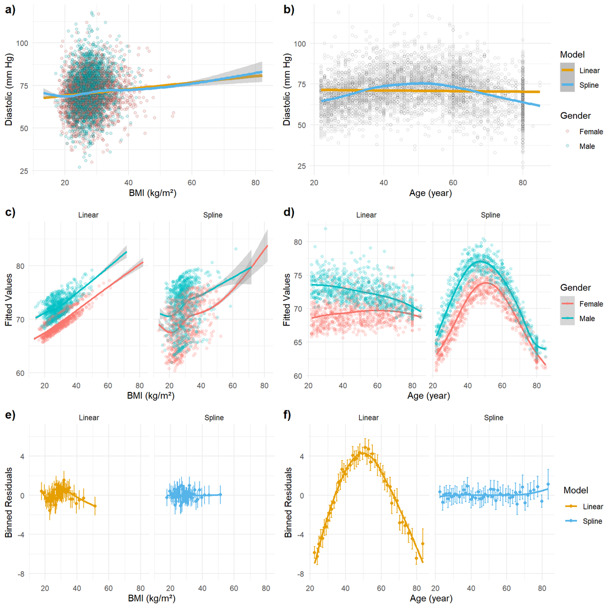

```r
raw_g <- ggpubr::ggarrange(raw_bmi,raw_age,
                           common.legend = TRUE,
                           labels = c('a)','b)'),legend='right')

fit_g <- ggpubr::ggarrange(fit_bmi, fit_age,
                           common.legend = TRUE,
                           labels = c('c)','d)'),legend='right')


res_g <- ggpubr::ggarrange(bmi_res,age_res,common.legend = TRUE,labels = c('e)','f)'),legend='right')


ggpubr::ggarrange(raw_g,fit_g,res_g,nrow = 3,ncol = 1)
```

- **Note: The trends are difficult to see in binned residuals plot with BMI because most data are squeezed in a small range. A possible solution is to separate BMI from age plots**

## Cross-Validation to determe number of Knots for Age

The matrix of the mean square errors (MSE) and standard deviations of choosing different knots show that the changing number of quantile knots or specific integer knots do not significantly impact the model. Although hold-on different years data set as validation data makes the performance slightly different, increasing the number of age knots does not significantly impact the model performance. The main reason is that the data diastolic has a quadratic (parabola-like), which only requires three knots to reach the goal, and more data knots will not help. More knots may hurt the performance when we have a relatively small amount of data. Still, it does not compromise the performance because we have enough data to prevent the model from overfitting by introducing too many knots.

```r
qs <- 5:22

cross_validation <- function(q_list=qs,base_model=ns_str,df=data) {
  len_q <- length(q_list)


  # leave out 2011-2012 because max age in the years is 80, which lead some issue to set up knots
  # as above
  # https://stat.ethz.ch/pipermail/r-devel/2011-May/061035.html

  years <- levels(df$years)

  len_year <- length(years)

  mse_mtx <- matrix(0, nrow = len_q+1, ncol = len_year)
  rownames(mse_mtx) <- c(c(q_list - 2),"ns_base")
  colnames(mse_mtx) <- years

  for (i in 1:len_q) {
    # number of knots = q - 2
    q <- q_list[i]
    for (j in 1:len_year) {
      # print(years[j])
      cv_train <- df[df$years != years[j], ]
      cv_test <- df[df$years == years[j], ]

      knots <- quantile(unique(cv_train$RIDAGEYR), 1:(q - 2) / (q - 1),names=FALSE)

      knots <- paste0(knots, collapse = ', ')
      ns_model <-
        paste0(
          'diastolic ~ ns(RIDAGEYR, knots = c(',
          knots,
          '),Boundary.knots=c(20,90))* RIAGENDR + ns(BMXBMI,knots = c(seq(15, 45, by = 5),seq(45,65,by=10)),Boundary.knots=c(10,80))'
        )


      cv_ns_model <- NA
      tryCatch({
        cv_ns_model <- lm(as.formula(ns_model), cv_train)

      },
      error = function(e) {
            print(paste0("years=",years[j],"raise errors:NA/NaN/Inf in foreign function call (arg 1)"))
            # print(ns_model)
          },
      finally = {
        mse_mtx[i, j] = NA
        }
      )
      if(is.list(cv_ns_model)){
        pred_vals <- predict(cv_ns_model, cv_test)
        mse_mtx[i, j] <- mean((pred_vals - cv_test$diastolic) ^ 2)
      }

    }

  }

  for (j in 1:len_year) {
      cv_train <- df[df$years != years[j], ]
      cv_test <- df[df$years == years[j], ]
      ns_model <- NA
      tryCatch({
        ns_model <- lm(as.formula(base_model), cv_train)

      },
      error = function(e) {
                print(paste0("years=",years[j],"raise errors:NA/NaN/Inf in foreign function call (arg 1)"))
          },
      finally = {
        mse_mtx[len_q+1, j] = NA
        }
      )
      if(is.list(ns_model)){
        pred_vals <- predict(ns_model, cv_test)
        mse_mtx[len_q+1, j] <- mean((pred_vals - cv_test$diastolic) ^ 2)
      }

    }

  mse_mtx
}

mse_mtx <- cross_validation()

knitr::kable(mse_mtx)
```

|  | 2003-2004 | 2005-2006 | 2007-2008 | 2009-2010 | 2011-2012 | 2013-2014 | 2015-2016 | 2017-2018 |
| --- | --- | --- | --- | --- | --- | --- | --- | --- |
| 3 | 113.5602 | 124.0469 | 115.0126 | 118.5525 | 116.5371 | 109.4847 | 112.2979 | 120.2385 |
| 4 | 113.4994 | 123.9942 | 115.0429 | 118.6197 | 116.5426 | 109.4805 | 112.2880 | 120.2672 |
| 5 | 113.4733 | 123.9850 | 115.0358 | 118.6314 | 116.5688 | 109.5003 | 112.2759 | 120.3162 |
| 6 | 113.5630 | 124.1064 | 115.0203 | 118.6872 | 116.5757 | 109.5018 | 112.2620 | 120.3115 |
| 7 | 113.5818 | 124.1113 | 115.0081 | 118.6397 | 116.6296 | 109.4470 | 112.2922 | 120.3498 |
| 8 | 113.5432 | 124.0994 | 115.0170 | 118.6193 | 116.7624 | 109.4225 | 112.2733 | 120.3489 |
| 9 | 113.5688 | 124.0917 | 115.0114 | 118.6120 | 116.7672 | 109.4436 | 112.2783 | 120.4204 |
| 10 | 113.4933 | 124.0935 | 114.9837 | 118.5994 | 116.8290 | 109.4447 | 112.2756 | 120.4607 |
| 11 | 113.5351 | 124.1027 | 114.9848 | 118.5816 | 116.8789 | 109.4331 | 112.2635 | 120.4276 |
| 12 | 113.5561 | 124.0701 | 114.9637 | 118.5446 | 116.8887 | 109.4180 | 112.2875 | 120.4356 |
| 13 | 113.5376 | 124.1952 | 114.9685 | 118.6658 | 116.8221 | 109.3793 | 112.2793 | 120.4882 |
| 14 | 113.4985 | 124.1797 | 114.9735 | 118.5944 | 116.7842 | 109.4230 | 112.3592 | 120.5365 |
| 15 | 113.5156 | 124.2435 | 114.9536 | 118.6554 | 116.7910 | 109.4364 | 112.3022 | 120.5086 |
| 16 | 113.5294 | 124.3061 | 115.0614 | 118.6856 | 116.8284 | 109.4007 | 112.3405 | 120.5320 |
| 17 | 113.5984 | 124.3127 | 115.0700 | 118.6802 | 116.8661 | 109.3849 | 112.3191 | 120.4858 |
| 18 | 113.6080 | 124.3444 | 115.0704 | 118.7538 | 116.8433 | 109.4678 | 112.3661 | 120.5183 |
| 19 | 113.7669 | 124.4174 | 115.0660 | 118.7373 | 116.9044 | 109.3895 | 112.2355 | 120.5554 |
| 20 | 114.0223 | 124.4656 | 115.1224 | 118.6938 | 116.8085 | 109.4560 | 112.3757 | 120.6510 |
| ns_base | 112.8085 | 122.5005 | 114.5491 | 117.9386 | 115.6831 | 109.4353 | 111.1788 | 118.7553 |

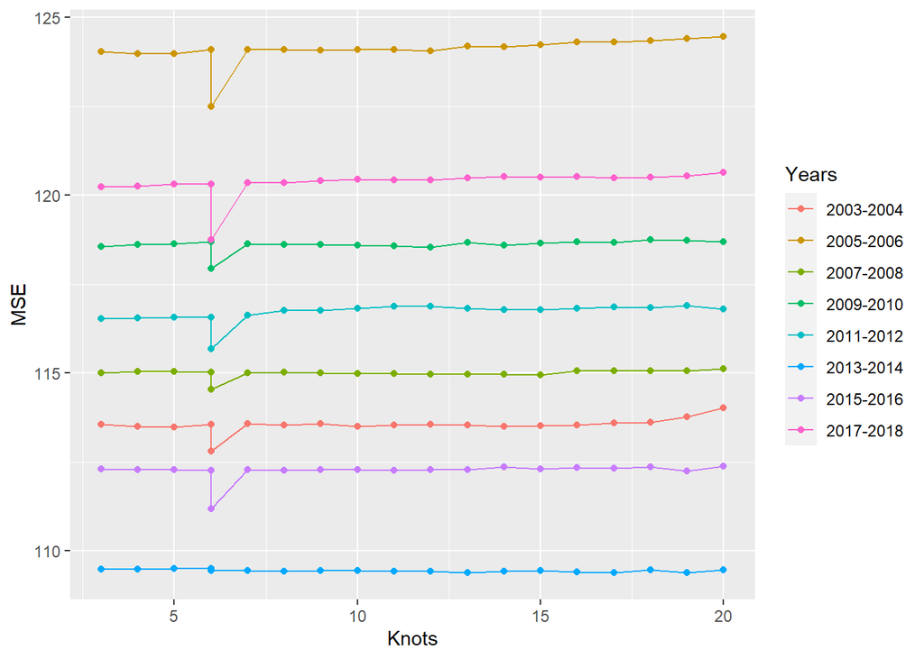

```r
mse_df <- as.data.frame(reshape2::melt(mse_mtx))
colnames(mse_df) <- c("Knots","Years","MSE")

mse_df[mse_df$Knots=="ns_base",]$Knots = 6
mse_df$Knots <- as.numeric(as.character(mse_df$Knots))
mse_df |> subset(!is.na(MSE)) |>
  ggplot(aes(Knots,MSE,color=Years)) + geom_line() + geom_point()
```

## Cross-Validation to Linear vs Spline

```r
cv_models <- function(model_list,df=data) {

  years <- levels(df$years)

  len_year <- length(years)

  mse_mtx <- matrix(0, nrow = len_year, ncol = length(model_list))
  rownames(mse_mtx) <- years
  colnames(mse_mtx) <- names(model_list)



  for (i in 1:len_year) {
      for(j in 1:length(model_list)){
      cv_train <- df[df$years != years[i], ]
      cv_test <- df[df$years == years[i], ]
      # print(model_list[j])
      ns_model <- lm(as.formula(model_list[j]), cv_train)

      pred_vals <- predict(ns_model, cv_test)
      mse_mtx[i,j] <- mean((pred_vals - cv_test$diastolic) ^ 2)


    }
}


  mse_mtx
}

model_list <- c(lm_str,ns_str)
names(model_list) <- c("linear","spline")
mse_mtx <- cv_models(model_list,data)

knitr::kable(mse_mtx)
```

|  | linear | spline |
| --- | --- | --- |
| 2003-2004 | 126.3039 | 112.8085 |
| 2005-2006 | 135.8971 | 122.5005 |
| 2007-2008 | 128.9056 | 114.5491 |
| 2009-2010 | 132.1313 | 117.9386 |
| 2011-2012 | 126.0317 | 115.6831 |
| 2013-2014 | 119.3860 | 109.4353 |
| 2015-2016 | 124.5069 | 111.1788 |
| 2017-2018 | 132.7688 | 118.7553 |

```r
mse_df <- as.data.frame(reshape2::melt(mse_mtx))
colnames(mse_df) <- c('years','model','MSE')

len_year <- length(levels(mse_df$years))
```

We can compare the model by check the residuals after running the regression. Further, we can confirm the model by using cross-validation. For example, we can compare the linear regression and spline regression with cross-validation, and the results show that spline model has much less errors.

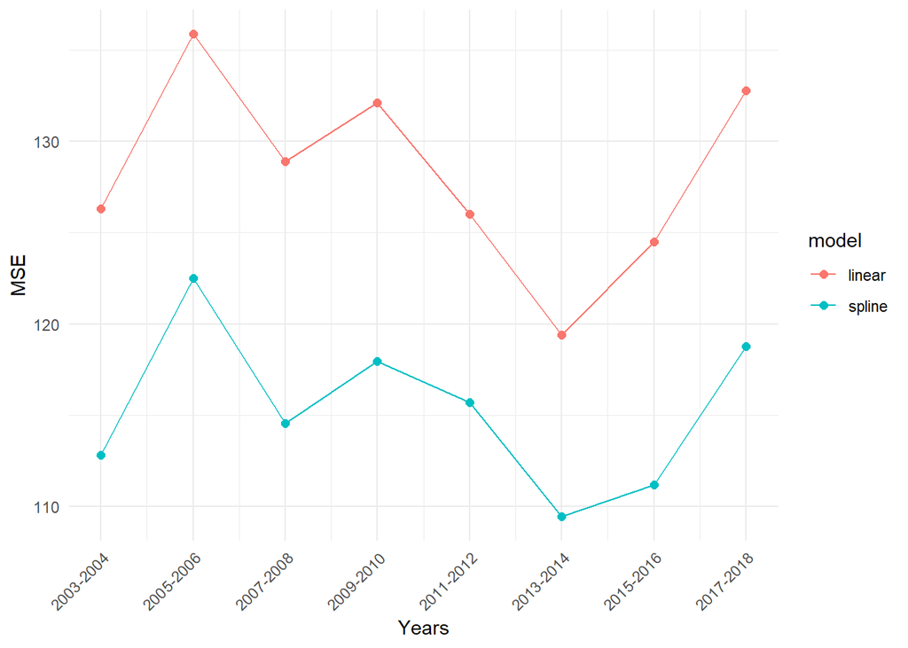

```r
mse_df |> ggplot(aes(x=as.numeric(years),y=MSE,color=model)) +
  geom_point(size=2)+ geom_line()+
  scale_x_continuous(breaks=seq(1,len_year,1),labels=levels(mse_df$years),
                     guide = guide_axis(angle = 45))+ xlab("Years")+
  theme_minimal()
```

## ANOVA LRT (Likelihood Ratio Test)

```r
print_anova <- function(anov_obj){
  for (a in attr(anov_obj,"heading")){
    cat(gsub(pattern = "\n", replacement = "  \n", x = a))
    }
  anov_df <- as.data.frame(anov_obj)
  anov_df <- round(anov_df,3)
  anov_df[!is.na(anov_df[,'Pr(>Chi)']) & anov_df[,'Pr(>Chi)'] <= 0.001, 'Pr(>Chi)'] <- "< 0.001"
  anov_df[is.na(anov_df)] <- ""

  knitr::kable(anov_df)
}
print_anova(anova(lm_base,ns_base,test="LRT"))
```

Analysis of Variance Table  
Model 1: diastolic ~ RIDAGEYR * RIAGENDR + BMXBMI + RIDRETH1  
Model 2: diastolic ~ ns(RIDAGEYR, knots = seq(30, 80, by = 10), Boundary.knots = c(20,  
90)) * RIAGENDR + ns(BMXBMI, knots = c(seq(15, 45, by = 5),  
seq(45, 65, by = 10)), Boundary.knots = c(10, 85)) + RIDRETH1

| Res.Df | RSS | Df | Sum of Sq | Pr(>Chi) |
| --- | --- | --- | --- | --- |
| 29638 | 3785310 |  |  |  |
| 29616 | 3396489 | 22 | 388820.202 | < 0.001 |

## Ethnicity and Years

```r
lm_no_race <- lm(diastolic ~ RIDAGEYR*RIAGENDR + BMXBMI, data)
lm_years <- lm(as.formula(paste0(lm_str," + years")), data)

ns_str_no_race <-
  'diastolic ~ ns(RIDAGEYR, knots = seq(30, 80, by = 10), Boundary.knots=c(20,90)) * RIAGENDR + ns(BMXBMI,knots = c(seq(15, 45, by = 5),seq(45,65,by=10)),Boundary.knots=c(10,85))'


ns_no_race <- lm(ns_str_no_race, data)
ns_years <- lm(as.formula(paste0(ns_str," + years")), data)
```

```r
print_anova(anova(lm_no_race,lm_base,test="LRT"))
```

Analysis of Variance Table  
Model 1: diastolic ~ RIDAGEYR * RIAGENDR + BMXBMI  
Model 2: diastolic ~ RIDAGEYR * RIAGENDR + BMXBMI + RIDRETH1

| Res.Df | RSS | Df | Sum of Sq | Pr(>Chi) |
| --- | --- | --- | --- | --- |
| 29642 | 3817937 |  |  |  |
| 29638 | 3785310 | 4 | 32627.772 | < 0.001 |

```r
sjPlot::tab_model(lm_no_race,lm_base,
                  dv.labels = c("lm_no_race", "lm_base"),
                  show.stat=TRUE,show.dev=TRUE)
```

|  | lm_no_race |  |  |  | lm_base |  |  |  |
| --- | --- | --- | --- | --- | --- | --- | --- | --- |
| Predictors | Estimates | CI | Statistic | p | Estimates | CI | Statistic | p |
| (Intercept) | 62.78 | 61.99 – 63.58 | 154.75 | **<0.001** | 61.30 | 60.44 – 62.15 | 140.41 | **<0.001** |
| RIDAGEYR | 0.01 | -0.00 – 0.02 | 1.87 | 0.061 | 0.01 | 0.00 – 0.02 | 2.40 | **0.016** |
| RIAGENDR [Male] | 6.56 | 5.77 – 7.36 | 16.17 | **<0.001** | 6.57 | 5.78 – 7.36 | 16.25 | **<0.001** |
| BMXBMI | 0.21 | 0.19 – 0.23 | 20.62 | **<0.001** | 0.21 | 0.19 – 0.23 | 20.88 | **<0.001** |
| RIDAGEYR * RIAGENDR [Male] | -0.07 | -0.08 – -0.05 | -8.62 | **<0.001** | -0.07 | -0.08 – -0.05 | -8.66 | **<0.001** |
| RIDRETH1 [Other Hispanic] |  |  |  |  | 0.53 | -0.01 – 1.07 | 1.91 | 0.057 |
| RIDRETH1 [Non-Hispanic White] |  |  |  |  | 0.71 | 0.34 – 1.09 | 3.70 | **<0.001** |
| RIDRETH1 [Non-Hispanic Black] |  |  |  |  | 2.62 | 2.19 – 3.05 | 11.89 | **<0.001** |
| RIDRETH1 [Other Race] |  |  |  |  | 3.01 | 2.48 – 3.53 | 11.15 | **<0.001** |
| Observations | 29647 |  |  |  | 29647 |  |  |  |
| R<sup>2</sup> / R<sup>2</sup> adjusted | 0.035 / 0.035 |  |  |  | 0.043 / 0.043 |  |  |  |
| Deviance | 3817937.461 |  |  |  | 3785309.689 |  |  |  |

```r
print_anova(anova(ns_no_race,ns_base,test="LRT"))
```

Analysis of Variance Table  
Model 1: diastolic ~ ns(RIDAGEYR, knots = seq(30, 80, by = 10), Boundary.knots = c(20,  
90)) * RIAGENDR + ns(BMXBMI, knots = c(seq(15, 45, by = 5),  
seq(45, 65, by = 10)), Boundary.knots = c(10, 85))  
Model 2: diastolic ~ ns(RIDAGEYR, knots = seq(30, 80, by = 10), Boundary.knots = c(20,  
90)) * RIAGENDR + ns(BMXBMI, knots = c(seq(15, 45, by = 5),  
seq(45, 65, by = 10)), Boundary.knots = c(10, 85)) + RIDRETH1

| Res.Df | RSS | Df | Sum of Sq | Pr(>Chi) |
| --- | --- | --- | --- | --- |
| 29620 | 3422719 |  |  |  |
| 29616 | 3396489 | 4 | 26229.249 | < 0.001 |

```r
sjPlot::tab_model(ns_no_race,ns_base,
                  dv.labels = c("ns_no_race", "ns_base"),
                  show.stat=TRUE,show.dev=TRUE)
```

|  | ns_no_race |  |  |  | ns_base |  |  |  |
| --- | --- | --- | --- | --- | --- | --- | --- | --- |
| Predictors | Estimates | CI | Statistic | p | Estimates | CI | Statistic | p |
| (Intercept) | 69.32 | 45.70 – 92.94 | 5.75 | **<0.001** | 67.19 | 43.66 – 90.73 | 5.60 | **<0.001** |
| RIDAGEYR [1st degree] | 9.46 | 8.33 – 10.60 | 16.35 | **<0.001** | 9.43 | 8.30 – 10.56 | 16.35 | **<0.001** |
| RIDAGEYR [2nd degree] | 11.81 | 10.23 – 13.38 | 14.66 | **<0.001** | 11.61 | 10.04 – 13.18 | 14.47 | **<0.001** |
| RIDAGEYR [3rd degree] | 9.79 | 8.41 – 11.18 | 13.83 | **<0.001** | 9.65 | 8.27 – 11.04 | 13.69 | **<0.001** |
| RIDAGEYR [4th degree] | 4.98 | 3.31 – 6.65 | 5.84 | **<0.001** | 4.98 | 3.32 – 6.65 | 5.87 | **<0.001** |
| RIDAGEYR [5th degree] | -0.72 | -2.56 – 1.12 | -0.77 | 0.441 | -0.91 | -2.74 – 0.93 | -0.97 | 0.334 |
| RIDAGEYR [6th degree] | 2.29 | -1.69 – 6.27 | 1.13 | 0.260 | 2.34 | -1.63 – 6.30 | 1.16 | 0.248 |
| RIDAGEYR [7th degree] | -3.25 | -8.31 – 1.81 | -1.26 | 0.208 | -2.85 | -7.90 – 2.19 | -1.11 | 0.267 |
| RIAGENDR [Male] | 2.43 | 0.84 – 4.02 | 2.99 | **0.003** | 2.34 | 0.76 – 3.92 | 2.90 | **0.004** |
| BMXBMI [1st degree] | -8.23 | -31.43 – 14.96 | -0.70 | 0.487 | -7.74 | -30.85 – 15.36 | -0.66 | 0.511 |
| BMXBMI [2nd degree] | -7.66 | -31.42 – 16.10 | -0.63 | 0.527 | -6.86 | -30.53 – 16.81 | -0.57 | 0.570 |
| BMXBMI [3rd degree] | -6.32 | -29.81 – 17.18 | -0.53 | 0.598 | -5.34 | -28.75 – 18.07 | -0.45 | 0.655 |
| BMXBMI [4th degree] | -5.37 | -29.04 – 18.30 | -0.44 | 0.657 | -4.53 | -28.12 – 19.06 | -0.38 | 0.707 |
| BMXBMI [5th degree] | -5.90 | -29.46 – 17.65 | -0.49 | 0.623 | -5.16 | -28.62 – 18.31 | -0.43 | 0.667 |
| BMXBMI [6th degree] | -4.84 | -28.49 – 18.81 | -0.40 | 0.688 | -4.11 | -27.67 – 19.46 | -0.34 | 0.733 |
| BMXBMI [7th degree] | -3.45 | -27.11 – 20.21 | -0.29 | 0.775 | -2.81 | -26.38 – 20.76 | -0.23 | 0.815 |
| BMXBMI [8th degree] | -7.39 | -31.36 – 16.58 | -0.60 | 0.546 | -6.77 | -30.65 – 17.11 | -0.56 | 0.578 |
| BMXBMI [9th degree] | 10.75 | -6.30 – 27.80 | 1.24 | 0.217 | 11.04 | -5.95 – 28.03 | 1.27 | 0.203 |
| BMXBMI [10th degree] | 0.08 | -46.49 – 46.65 | 0.00 | 0.997 | 0.65 | -45.74 – 47.05 | 0.03 | 0.978 |
| BMXBMI [11th degree] | 5.20 | -16.64 – 27.04 | 0.47 | 0.641 | 5.21 | -16.55 – 26.96 | 0.47 | 0.639 |
| RIDAGEYR [1st degree] * RIAGENDR [Male] | 2.17 | 0.53 – 3.82 | 2.60 | **0.009** | 2.23 | 0.59 – 3.86 | 2.67 | **0.008** |
| RIDAGEYR [2nd degree] * RIAGENDR [Male] | 0.64 | -1.63 – 2.91 | 0.55 | 0.580 | 0.73 | -1.53 – 3.00 | 0.64 | 0.525 |
| RIDAGEYR [3rd degree] * RIAGENDR [Male] | 0.02 | -1.97 – 2.02 | 0.02 | 0.981 | 0.09 | -1.89 – 2.07 | 0.09 | 0.929 |
| RIDAGEYR [4th degree] * RIAGENDR [Male] | 0.03 | -2.36 – 2.41 | 0.02 | 0.982 | -0.01 | -2.38 – 2.36 | -0.01 | 0.993 |
| RIDAGEYR [5th degree] * RIAGENDR [Male] | -3.10 | -5.71 – -0.49 | -2.33 | **0.020** | -2.99 | -5.59 – -0.40 | -2.26 | **0.024** |
| RIDAGEYR [6th degree] * RIAGENDR [Male] | 2.96 | -2.83 – 8.76 | 1.00 | 0.316 | 3.11 | -2.66 – 8.88 | 1.05 | 0.291 |
| RIDAGEYR [7th degree] * RIAGENDR [Male] | 0.94 | -6.41 – 8.29 | 0.25 | 0.802 | 0.97 | -6.35 – 8.29 | 0.26 | 0.795 |
| RIDRETH1 [Other Hispanic] |  |  |  |  | 0.39 | -0.12 – 0.91 | 1.50 | 0.134 |
| RIDRETH1 [Non-Hispanic White] |  |  |  |  | 1.32 | 0.96 – 1.68 | 7.13 | **<0.001** |
| RIDRETH1 [Non-Hispanic Black] |  |  |  |  | 2.61 | 2.20 – 3.02 | 12.45 | **<0.001** |
| RIDRETH1 [Other Race] |  |  |  |  | 2.84 | 2.33 – 3.34 | 11.02 | **<0.001** |
| Observations | 29647 |  |  |  | 29647 |  |  |  |
| R<sup>2</sup> / R<sup>2</sup> adjusted | 0.135 / 0.134 |  |  |  | 0.141 / 0.141 |  |  |  |
| Deviance | 3422718.735 |  |  |  | 3396489.486 |  |  |  |

```r
print_anova(anova(ns_base,ns_years,test="LRT"))
```

Analysis of Variance Table  
Model 1: diastolic ~ ns(RIDAGEYR, knots = seq(30, 80, by = 10), Boundary.knots = c(20,  
90)) * RIAGENDR + ns(BMXBMI, knots = c(seq(15, 45, by = 5),  
seq(45, 65, by = 10)), Boundary.knots = c(10, 85)) + RIDRETH1  
Model 2: diastolic ~ ns(RIDAGEYR, knots = seq(30, 80, by = 10), Boundary.knots = c(20,  
90)) * RIAGENDR + ns(BMXBMI, knots = c(seq(15, 45, by = 5),  
seq(45, 65, by = 10)), Boundary.knots = c(10, 85)) + RIDRETH1 +  
years

| Res.Df | RSS | Df | Sum of Sq | Pr(>Chi) |
| --- | --- | --- | --- | --- |
| 29616 | 3396489 |  |  |  |
| 29609 | 3377242 | 7 | 19247.362 | < 0.001 |

```r
sjPlot::tab_model(ns_base,ns_years,
                  dv.labels = c("lm_base", "ns_years"),
                  show.stat=TRUE,show.dev=TRUE)
```

|  | lm_base |  |  |  | ns_years |  |  |  |
| --- | --- | --- | --- | --- | --- | --- | --- | --- |
| Predictors | Estimates | CI | Statistic | p | Estimates | CI | Statistic | p |
| (Intercept) | 67.19 | 43.66 – 90.73 | 5.60 | **<0.001** | 68.75 | 45.28 – 92.23 | 5.74 | **<0.001** |
| RIDAGEYR [1st degree] | 9.43 | 8.30 – 10.56 | 16.35 | **<0.001** | 9.39 | 8.26 – 10.52 | 16.32 | **<0.001** |
| RIDAGEYR [2nd degree] | 11.61 | 10.04 – 13.18 | 14.47 | **<0.001** | 11.61 | 10.04 – 13.18 | 14.50 | **<0.001** |
| RIDAGEYR [3rd degree] | 9.65 | 8.27 – 11.04 | 13.69 | **<0.001** | 9.48 | 8.10 – 10.86 | 13.46 | **<0.001** |
| RIDAGEYR [4th degree] | 4.98 | 3.32 – 6.65 | 5.87 | **<0.001** | 4.88 | 3.22 – 6.54 | 5.76 | **<0.001** |
| RIDAGEYR [5th degree] | -0.91 | -2.74 – 0.93 | -0.97 | 0.334 | -0.91 | -2.75 – 0.93 | -0.97 | 0.331 |
| RIDAGEYR [6th degree] | 2.34 | -1.63 – 6.30 | 1.16 | 0.248 | 1.90 | -2.07 – 5.87 | 0.94 | 0.348 |
| RIDAGEYR [7th degree] | -2.85 | -7.90 – 2.19 | -1.11 | 0.267 | -3.34 | -8.40 – 1.72 | -1.29 | 0.196 |
| RIAGENDR [Male] | 2.34 | 0.76 – 3.92 | 2.90 | **0.004** | 2.28 | 0.70 – 3.86 | 2.83 | **0.005** |
| BMXBMI [1st degree] | -7.74 | -30.85 – 15.36 | -0.66 | 0.511 | -8.45 | -31.50 – 14.59 | -0.72 | 0.472 |
| BMXBMI [2nd degree] | -6.86 | -30.53 – 16.81 | -0.57 | 0.570 | -7.70 | -31.30 – 15.91 | -0.64 | 0.523 |
| BMXBMI [3rd degree] | -5.34 | -28.75 – 18.07 | -0.45 | 0.655 | -6.11 | -29.46 – 17.23 | -0.51 | 0.608 |
| BMXBMI [4th degree] | -4.53 | -28.12 – 19.06 | -0.38 | 0.707 | -5.39 | -28.92 – 18.13 | -0.45 | 0.653 |
| BMXBMI [5th degree] | -5.16 | -28.62 – 18.31 | -0.43 | 0.667 | -5.93 | -29.33 – 17.48 | -0.50 | 0.620 |
| BMXBMI [6th degree] | -4.11 | -27.67 – 19.46 | -0.34 | 0.733 | -5.01 | -28.51 – 18.50 | -0.42 | 0.676 |
| BMXBMI [7th degree] | -2.81 | -26.38 – 20.76 | -0.23 | 0.815 | -3.58 | -27.08 – 19.93 | -0.30 | 0.766 |
| BMXBMI [8th degree] | -6.77 | -30.65 – 17.11 | -0.56 | 0.578 | -7.66 | -31.47 – 16.16 | -0.63 | 0.529 |
| BMXBMI [9th degree] | 11.04 | -5.95 – 28.03 | 1.27 | 0.203 | 10.46 | -6.48 – 27.40 | 1.21 | 0.226 |
| BMXBMI [10th degree] | 0.65 | -45.74 – 47.05 | 0.03 | 0.978 | -1.38 | -47.65 – 44.89 | -0.06 | 0.953 |
| BMXBMI [11th degree] | 5.21 | -16.55 – 26.96 | 0.47 | 0.639 | 4.37 | -17.33 – 26.07 | 0.39 | 0.693 |
| RIDRETH1 [Other Hispanic] | 0.39 | -0.12 – 0.91 | 1.50 | 0.134 | 0.39 | -0.13 – 0.91 | 1.49 | 0.137 |
| RIDRETH1 [Non-Hispanic White] | 1.32 | 0.96 – 1.68 | 7.13 | **<0.001** | 1.28 | 0.92 – 1.64 | 6.94 | **<0.001** |
| RIDRETH1 [Non-Hispanic Black] | 2.61 | 2.20 – 3.02 | 12.45 | **<0.001** | 2.49 | 2.08 – 2.90 | 11.86 | **<0.001** |
| RIDRETH1 [Other Race] | 2.84 | 2.33 – 3.34 | 11.02 | **<0.001** | 2.57 | 2.06 – 3.09 | 9.83 | **<0.001** |
| RIDAGEYR [1st degree] * RIAGENDR [Male] | 2.23 | 0.59 – 3.86 | 2.67 | **0.008** | 2.27 | 0.64 – 3.90 | 2.72 | **0.006** |
| RIDAGEYR [2nd degree] * RIAGENDR [Male] | 0.73 | -1.53 – 3.00 | 0.64 | 0.525 | 0.77 | -1.49 – 3.03 | 0.67 | 0.503 |
| RIDAGEYR [3rd degree] * RIAGENDR [Male] | 0.09 | -1.89 – 2.07 | 0.09 | 0.929 | 0.17 | -1.80 – 2.15 | 0.17 | 0.863 |
| RIDAGEYR [4th degree] * RIAGENDR [Male] | -0.01 | -2.38 – 2.36 | -0.01 | 0.993 | -0.00 | -2.37 – 2.36 | -0.00 | 0.998 |
| RIDAGEYR [5th degree] * RIAGENDR [Male] | -2.99 | -5.59 – -0.40 | -2.26 | **0.024** | -2.97 | -5.56 – -0.38 | -2.25 | **0.025** |
| RIDAGEYR [6th degree] * RIAGENDR [Male] | 3.11 | -2.66 – 8.88 | 1.05 | 0.291 | 3.29 | -2.47 – 9.04 | 1.12 | 0.263 |
| RIDAGEYR [7th degree] * RIAGENDR [Male] | 0.97 | -6.35 – 8.29 | 0.26 | 0.795 | 1.06 | -6.23 – 8.36 | 0.29 | 0.775 |
| years2005-2006 |  |  |  |  | -0.97 | -1.52 – -0.43 | -3.49 | **<0.001** |
| years2007-2008 |  |  |  |  | -0.56 | -1.08 – -0.05 | -2.13 | **0.033** |
| years2009-2010 |  |  |  |  | -1.31 | -1.82 – -0.79 | -4.99 | **<0.001** |
| years2011-2012 |  |  |  |  | -0.04 | -0.58 – 0.49 | -0.16 | 0.871 |
| years2013-2014 |  |  |  |  | -1.29 | -1.82 – -0.77 | -4.83 | **<0.001** |
| years2015-2016 |  |  |  |  | -1.37 | -1.90 – -0.84 | -5.11 | **<0.001** |
| years2017-2018 |  |  |  |  | 1.13 | 0.59 – 1.67 | 4.08 | **<0.001** |
| Observations | 29647 |  |  |  | 29647 |  |  |  |
| R<sup>2</sup> / R<sup>2</sup> adjusted | 0.141 / 0.141 |  |  |  | 0.146 / 0.145 |  |  |  |
| Deviance | 3396489.486 |  |  |  | 3377242.125 |  |  |  |

## More Residual Plots

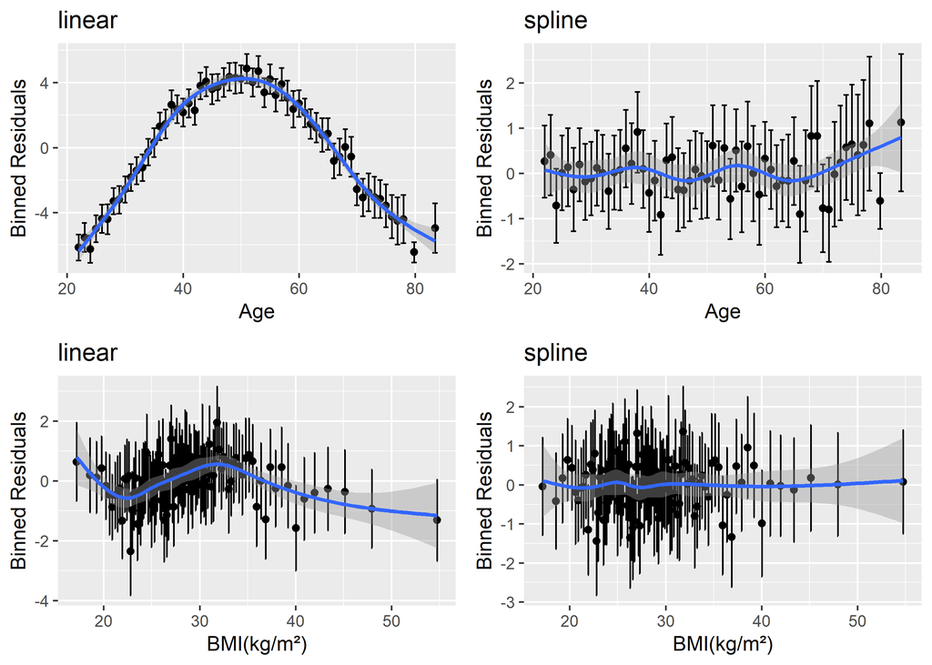

```r
lm_bmi <- plot_bins(data$BMXBMI, lm_base$residuals,xlab="BMI(kg/m²)",nbin=300)
ns_bmi <- plot_bins(data$BMXBMI, ns_base$residuals,xlab="BMI(kg/m²)",title="spline",nbin=300)
lm_age <- plot_bins(data$RIDAGEYR, lm_base$residuals,xlab="Age",nbin=300)
ns_age <- plot_bins(data$RIDAGEYR, ns_base$residuals,xlab="Age",title="spline",nbin=300)

ggarrange(lm_age,ns_age,lm_bmi,ns_bmi,ncol = 2,nrow = 2,common.legend = TRUE)
```